# Logistic Regression example

Marco Pasin

14 luglio 2019

Load ISLR package with all datasets.

```r
library("ISLR")
library("tidyverse")
```

Let’s use the `Smarket` dataset.

### Quickly explore data

```r
glimpse(Smarket)
```

```
## Observations: 1,250
## Variables: 9
## $ Year      <dbl> 2001, 2001, 2001, 2001, 2001, 2001, 2001, 2001, 2001...
## $ Lag1      <dbl> 0.381, 0.959, 1.032, -0.623, 0.614, 0.213, 1.392, -0...
## $ Lag2      <dbl> -0.192, 0.381, 0.959, 1.032, -0.623, 0.614, 0.213, 1...
## $ Lag3      <dbl> -2.624, -0.192, 0.381, 0.959, 1.032, -0.623, 0.614, ...
## $ Lag4      <dbl> -1.055, -2.624, -0.192, 0.381, 0.959, 1.032, -0.623,...
## $ Lag5      <dbl> 5.010, -1.055, -2.624, -0.192, 0.381, 0.959, 1.032, ...
## $ Volume    <dbl> 1.1913, 1.2965, 1.4112, 1.2760, 1.2057, 1.3491, 1.44...
## $ Today     <dbl> 0.959, 1.032, -0.623, 0.614, 0.213, 1.392, -0.403, 0...
## $ Direction <fct> Up, Up, Down, Up, Up, Up, Down, Up, Up, Up, Down, Do...
```

```r
summary(Smarket)
```

```
##       Year           Lag1                Lag2
##  Min.   :2001   Min.   :-4.922000   Min.   :-4.922000
##  1st Qu.:2002   1st Qu.:-0.639500   1st Qu.:-0.639500
##  Median :2003   Median : 0.039000   Median : 0.039000
##  Mean   :2003   Mean   : 0.003834   Mean   : 0.003919
##  3rd Qu.:2004   3rd Qu.: 0.596750   3rd Qu.: 0.596750
##  Max.   :2005   Max.   : 5.733000   Max.   : 5.733000
##       Lag3                Lag4                Lag5
##  Min.   :-4.922000   Min.   :-4.922000   Min.   :-4.92200
##  1st Qu.:-0.640000   1st Qu.:-0.640000   1st Qu.:-0.64000
##  Median : 0.038500   Median : 0.038500   Median : 0.03850
##  Mean   : 0.001716   Mean   : 0.001636   Mean   : 0.00561
##  3rd Qu.: 0.596750   3rd Qu.: 0.596750   3rd Qu.: 0.59700
##  Max.   : 5.733000   Max.   : 5.733000   Max.   : 5.73300
##      Volume           Today           Direction
##  Min.   :0.3561   Min.   :-4.922000   Down:602
##  1st Qu.:1.2574   1st Qu.:-0.639500   Up  :648
##  Median :1.4229   Median : 0.038500
##  Mean   :1.4783   Mean   : 0.003138
##  3rd Qu.:1.6417   3rd Qu.: 0.596750
##  Max.   :3.1525   Max.   : 5.733000
```

```r
?Smarket
```

We are going to use `direction` as response variable, and that is whether the market went up or down since the previous day. See if we can predict it as a binary response using **logistic regression**.

Lets do a scatter plot matrix and cross all variable with each others to spot any correlation. USe as color indicator our binary response variable.

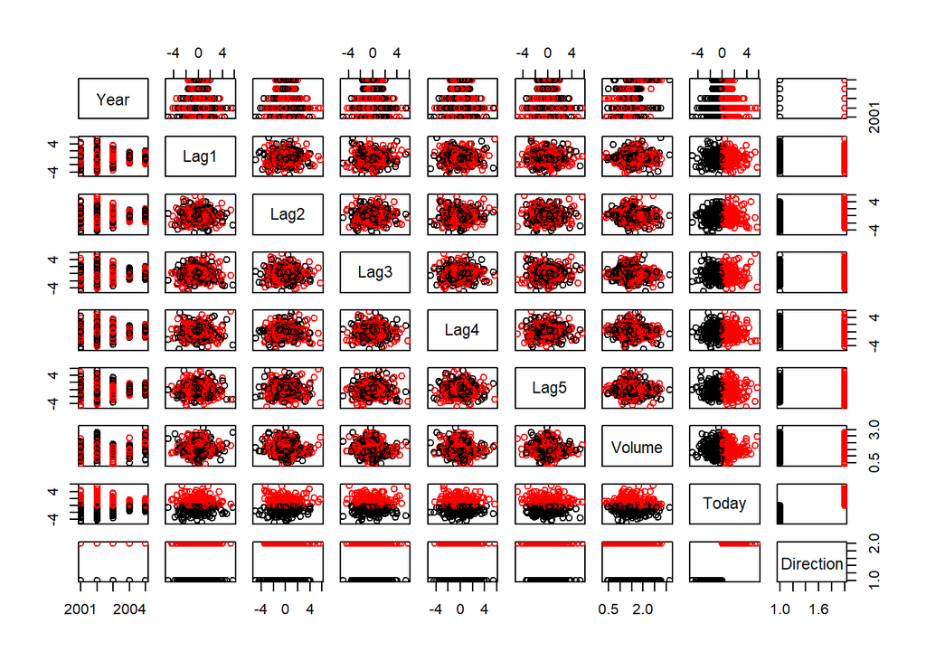

```r
Smarket %>%
   pairs(col = Smarket$Direction)
```

It looks a bit crowded!Doesn’t seem to be too much correlation going on here. Of course `Direction` is derived from the variable `Today`, and so up or down seems to make a division.

### Logistic Regression

Let’s fit a simple model using the `glm` function. Use all lags variables and also volume as predictors. And use **family equals binomial** which tells `glm` to fit a logistic regression model instead of one of the many other models that can be fit to the GLM.

```r
glm_fit <- Smarket %>%
  glm(Direction ~ Lag1 + Lag2 + Lag3 + Lag4 + Lag5 + Volume, .,
      family = binomial)

summary(glm_fit)
```

```
##
## Call:
## glm(formula = Direction ~ Lag1 + Lag2 + Lag3 + Lag4 + Lag5 +
##     Volume, family = binomial, data = .)
##
## Deviance Residuals:
##    Min      1Q  Median      3Q     Max
## -1.446  -1.203   1.065   1.145   1.326
##
## Coefficients:
##              Estimate Std. Error z value Pr(>|z|)
## (Intercept) -0.126000   0.240736  -0.523    0.601
## Lag1        -0.073074   0.050167  -1.457    0.145
## Lag2        -0.042301   0.050086  -0.845    0.398
## Lag3         0.011085   0.049939   0.222    0.824
## Lag4         0.009359   0.049974   0.187    0.851
## Lag5         0.010313   0.049511   0.208    0.835
## Volume       0.135441   0.158360   0.855    0.392
##
## (Dispersion parameter for binomial family taken to be 1)
##
##     Null deviance: 1731.2  on 1249  degrees of freedom
## Residual deviance: 1727.6  on 1243  degrees of freedom
## AIC: 1741.6
##
## Number of Fisher Scoring iterations: 3
```

The summary tells something about the fit:

- seems like none of the coefficient is significant here
- we also didn’t see strong correlations above

We can make prediction on the training data we used to train the model, which will return a vector of fitted probabilities.

```r
glm_probs <- glm_fit %>%
  predict(Smarket, type = "response")

glm_probs[1:5]
```

```
##         1         2         3         4         5
## 0.5070841 0.4814679 0.4811388 0.5152224 0.5107812
```

Looking at the first five, we see that they are very close to 50%, which, again, is not surprising .We don’t expect to get strong predictions in this case. So this is a prediction whether the market is up or down based on the lags and other predictions.

We can turn these probabilities into classifications by thresholding at 0.5. We do it by using the if/else command and create a vector of true and falses.

```r
glm_pred <- ifelse(glm_probs > 0.5, "Up", "down")
```

Finally we can make a table of `glm_pred`, which is our ups and downs from our prediction, against the true direction.

```r
attach(Smarket)
table(glm_pred, Direction)
```

```
##         Direction
## glm_pred Down  Up
##     down  145 141
##     Up    457 507
```

- On the diagonal is where we do correct classification, while
- on the off diagonals is where we make mistakes.

We see from our table that there is lot of elements on the off diaginals. We can actually get our mean classification performance.

```r
mean(glm_pred==Direction)
```

```
## [1] 0.4056
```

Check out `tidymodels` and `recipes` package to train/test …